# Rozkłady prawdopodobieństwa. Hipotezy statystyczne i ich weryfikacje z wykorzystaniem języka R - raport

Krzysztof Stawarz

2023-01-06

Na początek załaduje potrzebne w poniższym raporcie pakiety:

```r
library(ggplot2)
library(ggpubr)
library(scales)
```

## Rozkład normalny (Gauss’a)

$\mu$ (inaczej $\mu_{x}$ lub $EX$) - wartość oczekiwana zmiennej x, często średnia (arytemtyczna lub ważona)

W R do wygenerowania wartości w rozkładzie Gauss’a stosujemy wbudowaną funkcję **rnorm()** (r od słówka *random*):

```r
rnorm(n=10)
```

```
##  [1]  1.1341937 -1.1136460  0.6237201  1.6397443 -0.6207626 -0.5038286
##  [7]  0.1075046 -1.0700452  1.0839070  3.5212800
```

```r
rnorm(n=10, mean=100)
```

```
##  [1]  99.03461 100.32382 102.41162 100.19478  99.74187  98.83051 100.22682
##  [8]  99.37272  99.92424 100.08632
```

```r
rnorm(n=10, mean=100, sd=20)
```

```
##  [1]  63.03392 115.99637 125.93672  72.67156  99.38690 108.90453 102.70118
##  [8]  87.71612 105.79394 103.94474
```

Domyślne wartości argumentów **rnorm()**:  
- mean = 0  
- sd = 1  
czyli dokładnie takie jak w znormalizowanym rozkładzie Gaussa $N(0, 1)$.

### Gęstość rozkładu normalnego

Do wyznaczenia **gęstości** (w statystyce prawodpodobieństwa wystąpienia konkretnej wartości dla danego rozkładu) używamy wbudowanej funkcji **dnorm()** (d od słówka *density*):

```r
rand_gauss_numb = rnorm(3)
rand_gauss_numb
```

```
## [1] -1.1566459 -0.5845703  1.0091443
```

```r
dnorm(rand_gauss_numb)
```

```
## [1] 0.2043638 0.3362838 0.2397581
```

Nie jest możliwe precyzyjne wyliczenie tego prawdopodobieństwa dla rozkładu normalnego ( Dlaczego?)

Rozkład normalny jest przykładem rozkładu ciągłej zmiennej losowej. Taki zbiór charakteryzuje się, jak sama nazwa mówi, ciągłością. Zarówno dziedziną, jak i zbiorem wartości funkcji gęstości prawdopodobieństwa jest zbiór liczb rzeczywistych $R$. Co oznacza, że prawdopodobieństwo wylosowania konkretnej liczby z takiego zbioru jest de facto równe 0. Można za to obliczyć prawdopodobieństwo, że zmienna znajdzie się w konkretnym przedziale.

```r
dnorm(10, 0, 1)
```

```
## [1] 7.694599e-23
```

Funckja **dnorm()** może przyjmować, podobnie jak rnorm(), argument **mean=** oraz **sd=**. Domyślnie są to wartośći rozkładu normalnego $N(0,1)$.

### Wykresik

Rozkład Gauss’a jest fajny m.in. dlatego, że wykres gęstości prawdopobieństwa ów rozkładu ma interesujący kształt. Narysujmy sobie jeden!

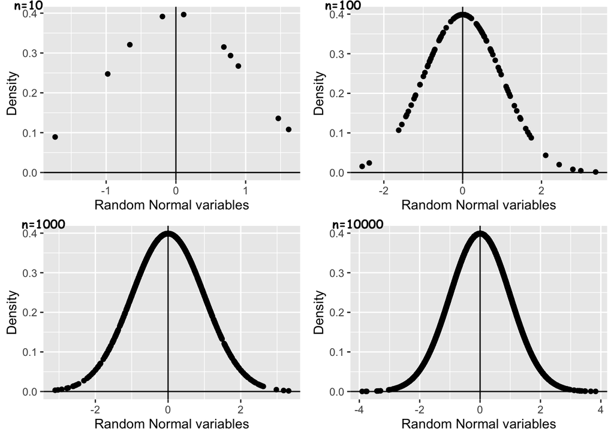

```r
dziedzina1 = rnorm(10)
dziedzina2 = rnorm(100)
dziedzina3 = rnorm(1000)
dziedzina4 = rnorm(10000)

wartosci1 = dnorm(dziedzina1)
wartosci2 = dnorm(dziedzina2)
wartosci3 = dnorm(dziedzina3)
wartosci4 = dnorm(dziedzina4)

dane1 = data.frame(dziedzina1, wartosci1)
dane2 = data.frame(dziedzina2, wartosci2)
dane3 = data.frame(dziedzina3, wartosci3)
dane4 = data.frame(dziedzina4, wartosci4)

par(mfrow=c(2, 2))


plot1 = ggplot(dane1) + aes(x=dziedzina1, y=wartosci1) + geom_point() + labs(x="Random Normal variables", y="Density") + geom_vline(xintercept = 0) +geom_hline(yintercept = 0)
plot2 = ggplot(dane2) + aes(x=dziedzina2, y=wartosci2) + geom_point() + labs(x="Random Normal variables", y="Density") + geom_vline(xintercept = 0) +geom_hline(yintercept = 0)
plot3 = ggplot(dane3) + aes(x=dziedzina3, y=wartosci3) + geom_point() + labs(x="Random Normal variables", y="Density") + geom_vline(xintercept = 0) +geom_hline(yintercept = 0)
plot4 = ggplot(dane4) + aes(x=dziedzina4, y=wartosci4) + geom_point() + labs(x="Random Normal variables", y="Density") + geom_vline(xintercept = 0) +geom_hline(yintercept = 0)

ggarrange(plot1, plot2, plot3, plot4,
          labels = c("n=10", "n=100", "n=1000", "n=10000"),
          ncol = 2, nrow = 2,
          label.y = 1.02,
          font.label = list(size = 10,
                            color = "black",
                            face = "bold",
                            family = "Comic Sans MS"))
```

Kształt tego wykresu nazywamy “krzywą dzwonowąXD” - ang. *bell curve*.

### Dystrybuanta rozkładu normalnego

**Dystrybuanta** rozkładu prawdopodobieństwa to funkcja, przyporządkowująca argumentowi wartość prawdopodobieństwa, że losowo wybrana liczba jest mniejsza bądź równa temu argumentowi.

W R do liczenia dystrybuanty służy funkcja **pnorm()**. Sprawdźmy, czy reguła **“Trzech sigm”** jest prawdziwa:

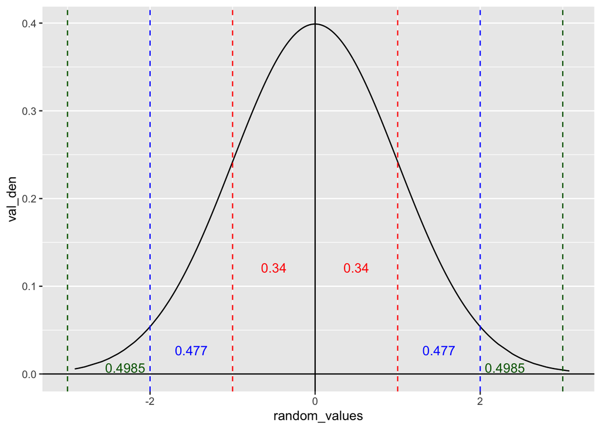

```r
mean = 0
sd = 1
random_values = rnorm(1000, mean, sd)

val_den = dnorm(random_values)

ans = data.frame(random_values, val_den)

sigma1 = pnorm(sd) - pnorm(-sd)
sigma2 = pnorm(2*sd) - pnorm(-2*sd)
sigma3 = pnorm(3*sd) - pnorm(-3*sd)

ggplot(ans, aes(x = random_values, y = val_den)) +
geom_line() +
geom_vline(xintercept=0) + geom_hline(yintercept=0) +
geom_vline(xintercept=sd, linetype="dashed", color="red") +
annotate("text",
          x=sd/2,
          y=dnorm(sd)/2,
          label = (round(sigma1,2)/2),
          color = "red") +
geom_vline(xintercept = -sd, linetype= "dashed", color="red") +
annotate("text",
         x=-sd/2,
         y=dnorm(-sd)/2,
         label = (round(sigma1,2)/2),
         color = "red") +
geom_vline(xintercept = 2*sd, linetype= "dashed", color="blue") +
annotate("text",
          x=(3*sd)/2,
          y=dnorm(2*sd)/2,
          label = (round(sigma2,3)/2),
          color = "blue") +
geom_vline(xintercept = -2*sd, linetype= "dashed", color="blue") +
annotate("text",
          x=(-3*sd)/2,
          y=dnorm(2*sd)/2,
          label = (round(sigma2,3)/2),
          color = "blue") +
geom_vline(xintercept = 3*sd, linetype= "dashed", color = "darkgreen") +
annotate("text",
          x=(5*sd)/2 - 0.2,
          y=dnorm(3*sd)/2 + 0.005,
          label = (round(sigma3,3)/2),
          color = "darkgreen") +
geom_vline(xintercept = -3*sd, linetype= "dashed", color = "darkgreen") +
annotate("text",
          x=(-5*sd)/2 + 0.2,
          y=dnorm(3*sd)/2 + 0.005,
          label = (round(sigma3,3)/2),
          color = "darkgreen")
```

```r
sigma1
```

```
## [1] 0.6826895
```

```r
sigma2
```

```
## [1] 0.9544997
```

```r
sigma3
```

```
## [1] 0.9973002
```

Wszystko się zgadza!

Czym jest data.frame, a czym jest geom_line()?

1. **data.frame()** to polecenie, pozwalające uwtorzyć ramkę danych, czyli jedną z najpopularniejszych struktur danych w języku R.
2. **geom_line()** to polecenie dodające tzw. **warstwe geometryczną** do wykresu ggplot. To jedna z funkcji, która pozwala na narysowanie **liniowego** wykresu na podstawie danych wejściowych. Służy do tworzenia wizualizacji danych. Pozwala również na narysowanie **linii** pomiędzy poszczególnymi punktami danych. Pokażę teraz róznicę między wykresami z różnymi warstwami geometrycznymi:

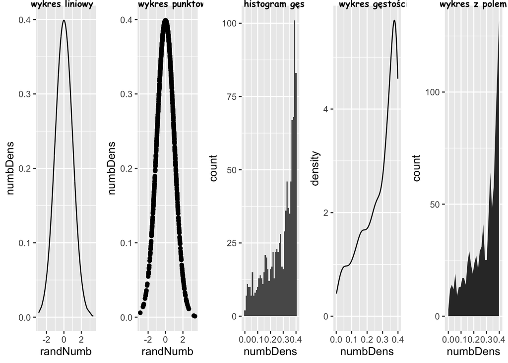

```r
rm(list = ls()) # usuwam wszystkie poprzednie zmienne, gdyż nie chcę zastanawiać się, czy już tak nazwałem jakąś zmienną wcześniej

randNumb = rnorm(1000)
numbDens = dnorm(randNumb)
data = data.frame(randNumb, numbDens)


linePlot = ggplot(data, aes(x=randNumb, y=numbDens)) + geom_line()
pointPlot = ggplot(data, aes(x=randNumb, y=numbDens)) + geom_point()
histPlot = ggplot(data, aes(numbDens)) + geom_histogram(binwidth = 0.01)
densPlot = ggplot(data, aes(numbDens)) + geom_density()
areaPlot = ggplot(data, aes(x = numbDens)) + geom_area(stat = "bin")

ggarrange(linePlot, pointPlot, histPlot, densPlot, areaPlot,
          labels = c("wykres liniowy", "wykres punktowy", "histogram gęstości", "wykres gęstości", "wykres z polem"),
          ncol = 5, nrow = 1,
          label.y = 1.01,
          font.label = list(size = 9,
                            color = "black",
                            face = "bold",
                            family = "Comic Sans MS"))
```

Powtórzymy pytanie, czym jest nasze prawdopodobieństwo?

Nasze prawdopodobieństwo to pole pod wykresem, inaczej - całka.

Dystrybuanta jest funkcją niemalejącą. Narysujmy jej wykres dla rozkładu normalnego:

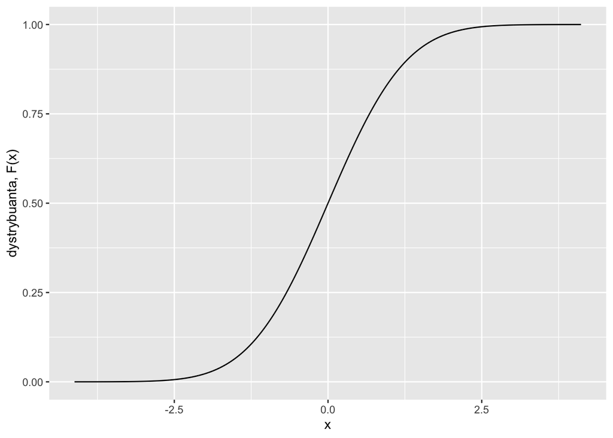

```r
liczby = rnorm(30000)
dane = data.frame(liczby, pnorm(liczby))
ggplot(dane, aes(x=liczby, y=pnorm(liczby))) + geom_line() + labs(x="x", y="dystrybuanta, F(x)")
```

Swoją drogą, wykres dystrybuanty rozkładu normlanego bardzo kojarzy mi się z wykresem funkcji **tanh(x)**:

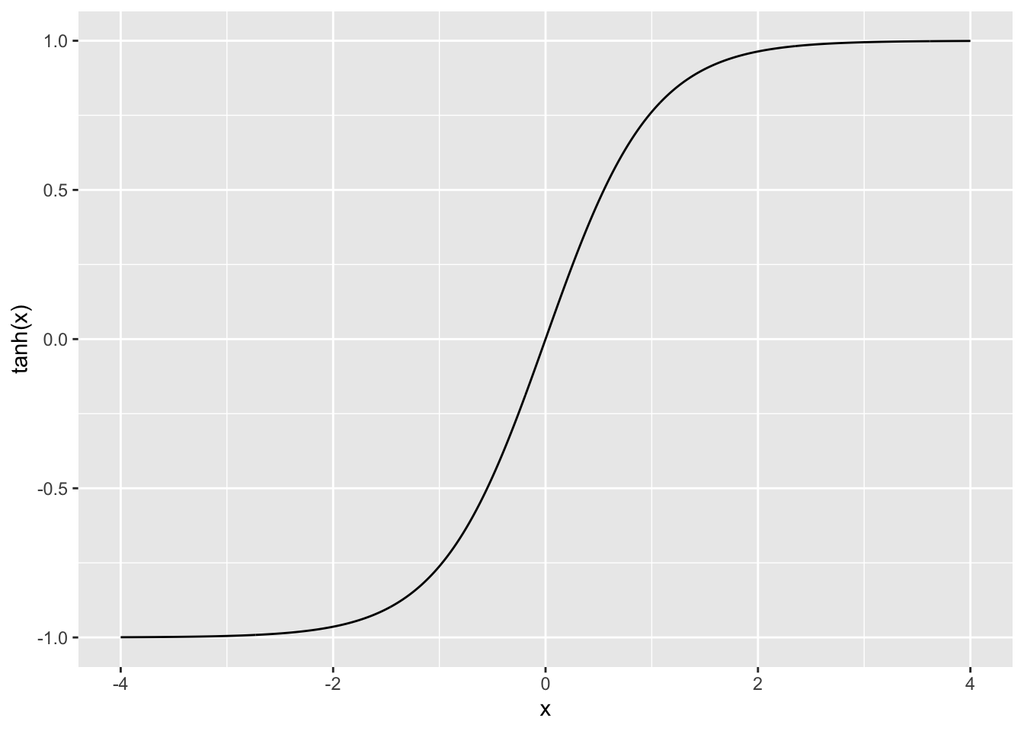

```r
x = seq(from=-4, to=4, by=0.01)
y = (exp(x)-exp(-x))/(exp(x)+exp(-x)) # wzór na tanh(x)
data = data.frame(x, y)
ggplot(data, aes(x=x, y=y)) + geom_line() + labs(x="x", y="tanh(x)")
```

W języku R funkcja odwrotna do pnorm() nosi nazwę **qnorm()**.  
liczba -> pnorm(liczba) -> dystrybuanta  
dystrybuanta -> qnorm(dystrybuanta) -> liczba

```r
x = 1
y = pnorm(1)
z = qnorm(y)

all.equal(x, z)
```

```
## [1] TRUE
```

Otrzymaliśmy T, więc się zgadza.

## Rozkład dwumianowy (Bernoulli’ego)

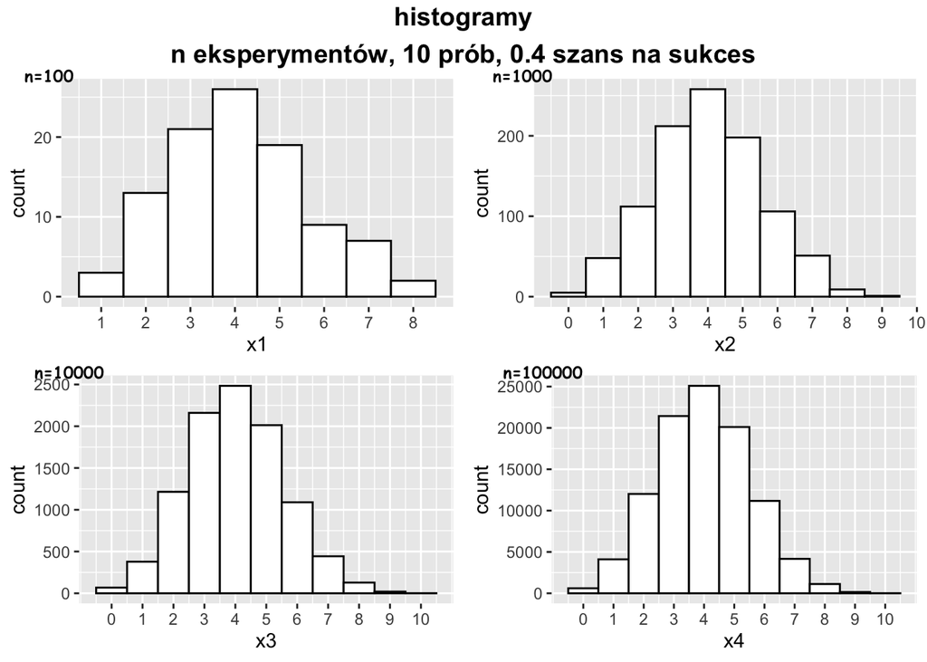

```r
x1 = rbinom(n=100, size=10, prob=0.4)
x2 = rbinom(n=1000, size=10, prob=0.4)
x3 = rbinom(n=10000, size=10, prob=0.4)
x4 = rbinom(n=100000, size=10, prob=0.4)

p1 = ggplot(data.frame(x1), aes(x = x1)) +
  geom_histogram(colour = 1, fill = "white", binwidth=1) +  scale_x_continuous(breaks=0:10)

p2 = ggplot(data.frame(x2), aes(x = x2)) +
  geom_histogram(colour = 1, fill = "white", binwidth=1) + scale_x_continuous(breaks=0:10)

p3 = ggplot(data.frame(x3), aes(x = x3)) +
  geom_histogram(colour = 1, fill = "white", binwidth=1) + scale_x_continuous(breaks=0:10)

p4  = ggplot(data.frame(x4), aes(x = x4)) +
  geom_histogram(colour = 1, fill = "white", binwidth=1) + scale_x_continuous(breaks=0:10)

main_p = ggarrange(p1, p2, p3, p4,
          labels = c("n=100", "n=1000", "n=10000", "n=100000"),
          ncol = 2, nrow = 2,
          label.y = 1.02,
          font.label = list(size = 9,
                            color = "black",
                            face = "bold",
                            family = "Comic Sans MS"))

annotate_figure(main_p, top = text_grob("histogramy\nn eksperymentów, 10 prób, 0.4 szans na sukces",
               color = "black", face = "bold", size = 14))
```

Ma to sens, oczekujemy z takiego eksperymentu 4 sukcesy ($n*p$), więc słupek najwyższy przy wartości 4. Zarówno na lewo i na prawo od niego słupki się zmniejszają, bo szansa na inne ilości sukcesów SUKCESYWNIE się zmniejszają.

### Dystrybuanta rozkładu dwumianowego

Dystrybuanta owa mówi nam o ilości sukcesów NIE-WIEKSZEJ niż argument do niej podany. Do liczenia gęstości prawdopodobieństwa rozkładu dwumianowego służy funkcja **dbinom()**, a do dystrybuanty **pbinom()**:

```r
tenChance = dbinom(10, size=10, prob=0.4)
tenChance
```

```
## [1] 0.0001048576
```

```r
tenOrLessChance = pbinom(10, size=10, prob=0.4)
tenOrLessChance
```

```
## [1] 1
```

Jak możemy się spodziewać, prawdopodobieństwo osiągnięcia 10-ciu sukcesów w 10-ciu próbach przy prawdopodobieństwe jednego p=0.4 jest malutkie. Natomiast szansa na 10 LUB MNIEJ sukcesów jest równa 1!

Wykres gęstości vs dystrybuanty:

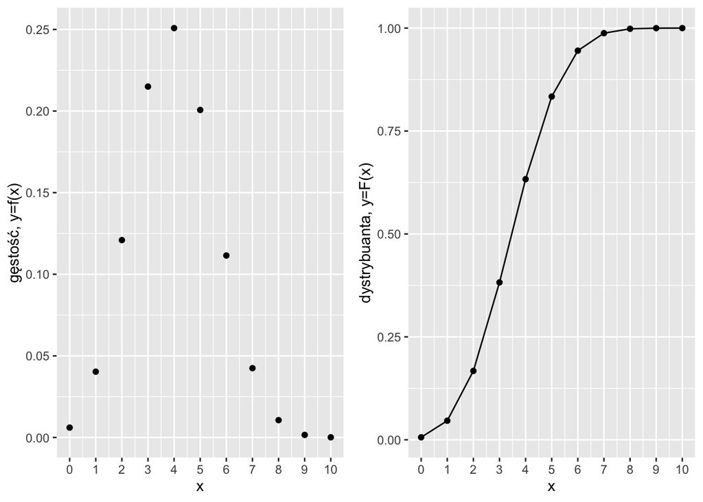

```r
mozliwe_wartosci_sukcesow = 0:10
prawdopodobienstwo = dbinom(mozliwe_wartosci_sukcesow, size=10, prob=0.4)
dystrybuanta = pbinom(mozliwe_wartosci_sukcesow, size=10, prob=0.4)

p1 = ggplot(data.frame(x=mozliwe_wartosci_sukcesow, y=prawdopodobienstwo), aes(x=x, y=y)) + geom_point() + scale_x_continuous(breaks=0:10) + labs(x="x", y="gęstość, y=f(x)")
p2 = ggplot(data.frame(x=mozliwe_wartosci_sukcesow, y=dystrybuanta), aes(x=x, y=y)) + geom_line() + geom_point() + scale_x_continuous(breaks=0:10) + labs(x="x", y="dystrybuanta, y=F(x)")
ggarrange(p1, p2,
          ncol = 2, nrow = 1)
```

## Zadanie 1.

Korzystając z dowolnych źródeł informacji odpowiedz na poniższe pytania (nie przepisuj!).  
**1.1 Co to jest hipoteza statystyczna?**  
Twierdzenie dotyczące populacji  
**1.2 Jakie są podstawowe rodzaje hipotez statystycznych?**  
Parametryczna / nieparametrzyczna  
**1.3 Co to jest weryfikacja hipotezy? Kiedy się odbywa?**  
Testowanie hipotez  
**1.4 Czym są testy statystyczne parametryczne, a czym nieparametryczne?**  
Test parametryczny to testowanie hipitezy paramterycznej, a niepar niepar  
**1.5 Co to jest hipoteza zerowa?**  
Hipoteza pierwsza?  
**1.6 Co to jest hipoteza alternatywna?**  
Odwrotność zerowej?  
**1.7 Co rozstrzyga test statystyczny?**  
Prawdziwość hipotezy statystycznej  
**1.8 Co to jest błąd I rodzaju?**  
Kiedy hipoteza jest prtawdziwa ale odrzucona  
**1.9 Co to jest błąd II rodzaju?**  
Kiedy hipoteza nie jest prawdziwa i nie zostaje odrzucona  
**1.10 Co to jest test istotności, a czym poziom istotności?**  
Test istotności to inna nazwa na test parametryczny, poziom istotnosci to prawdopodobienstwo popelnienia bledu I rodzaju  
**1.11 Co to jest moc testu?**  
Może jak dobrze wykrywa różnice i błędy?  
**1.12 Wymień etapy weryfikacji hipotez**  
1. Przyjęcie założeń,  
2. Otrzymanie rozkładu próby (prób),  
3. Wyznaczenie poziomu istotności obszaru krytycznego,  
4. Przeprowadzenie badań i wyliczenie statystyki testu,  
5. Podjęcie decyzji.  
**1.13 Czym jest obszar krytyczny testu?**  
To zakres, jeśli w nim statystyka się znajduje to znaczy że powinniśmy odrzucić hipotezę zerową na rzecz alternatywnej

## Zadanie 2.

```r
# Wzrost pewnej grupy osób opisany jest rozkładem normalnym o wartości oczekiwanej 173 cm i odchyleniu standardowym 6 cm.
mean = 173
sd = 6

# 2.1 Jakie jest prawdopodobieństwo, że losowo wybrana osoba ma nie więcej, niż 179 cm wzrostu?
pnorm(179, mean=mean, sd=sd)
```

```
## [1] 0.8413447
```

```r
# 2.2 Jaka jest frakcja osób mających wzrost pomiędzy 167 i 180 cm?
pnorm(180, mean=mean, sd=sd) - pnorm(167, mean=mean, sd=sd)
```

```
## [1] 0.7196722
```

```r
# 2.3 Jakie jest prawdopodobieństwo, że losowo wybrana osoba ma więcej, niż 181 cm wzrostu?
1 - pnorm(181, mean=mean, sd=sd)
```

```
## [1] 0.09121122
```

```r
# 2.4 Wyznacz wartość wzrostu, której nie przekracza 60% badanej populacji
qnorm(0.6, mean=mean, sd=sd)
```

```
## [1] 174.5201
```

Krzysztof Stawarz